# Final Project Summary

Catherine Zhang

2025-04-14

```r
library(tidyverse)
library(janitor)
library(striprtf)
library(dplyr)
library(readxl)
library(lubridate)
library(writexl)
library(tidytext)
library(stringr)
library(rio)
#setwd('D:/comp_text_class/project/dataset/summary homework')
```

# **Dataset Descripton**

**Data Source:** Nexis Uni

**Search Query:** “vasectomy or vasectomies”

**Date Range:** January 1, 2000 to December 31, 2025

**Language:** English

**Timestamp of Search:** 12 April 2025, 16:08

### **China Results Search Summary**

The search was limited to news from the region “China” (under the “News Search by Region: China” criteria).

**Filter Settings:** All Authors, All Companies, All Subjects, All Industries, and Source Type set to “All”.

**Source Location:** China

**Results Found:** 76 articles

**Notes:** The query focused on the terms “vasectomy” or “vasectomies” within the specified date range with the language restriction set to English. Given the lower number of results, the Chinese dataset provides a relatively smaller sample reflecting how this topic is reported in the context of China.

### **United States Results Search Summary**

A separate search was conducted for the region “United States” (using the “News Search by Region: United States” criteria), with a broader specification for the source type.

**Filter Settings:** All Authors, All Companies, All Subjects, All Industries. The Source Type includes Newspapers, Web-based Publications, Industry Trade Press, Magazines & Journals, Aggregate News Sources, Law Reviews & Journals, and Legal News.

**Source Location:** United States

**Results Found:** 4,279 articles

**Sampling:** From these 4,279 U.S. search results, a random sample of 2,000 articles was extracted for further analysis.

**Notes:** This larger sample reflects a robust media environment covering the topic of vasectomies in the U.S. context, offering a diverse range of publication types.

**Overall Dataset Description:** The complete dataset comprises news articles about vasectomies captured from Nexis Uni covering a 25-year period. The U.S. data, with 4,279 results, is significantly larger than the China data (76 results); however, for analytical tractability, a random sample of 2,000 U.S. articles was selected. Both searches were restricted to articles in English, ensuring consistency in language across regions.

This dataset is valuable for quantitative and qualitative analysis, such as topic modeling or trend analysis over time, and provides a cross-regional comparison of media coverage on vasectomy-related news.

# **Research Questions**

**RQ1:** What percentage of media coverage from the U.S. and China primarily focuses on a) medical issues, b) contraceptive decision-making, or c) political/policy contexts? (Media frame and agenda setting)

**RQ2:** How frequently is the term “Roe v. Wade” mentioned in U.S. media coverage of vasectomy, and how frequently is the “national population policy” (or related terms) mentioned in Chinese media coverage of vasectomy?

**RQ3:** How do sentiment scores derived from the AFINN lexicon differ between U.S. and Chinese media coverage of vasectomy, and what proportion of articles in each country can be classified as positive, neutral, or negative based on these scores? (sentiment analysis)

# **Codebook**

**RQ1: What percentage of media coverage from the U.S. and China primarily focuses on a) medical issues, b) contraceptive decision-making, or c) political/policy contexts? (Media frame and agenda setting)**

The coding Scheme is adopted from Framing dimensions from Boydstun et al. (2014). I picked 3 categories to study:

1. Health and safety: health care, sanitation, public safety
2. Cultural identity: traditions, customs, or values of a social group in relation to a policy issue
3. Policy prescription and evaluation: discussion of specific policies aimed at addressing problems

Based on this defination of the different categories, I developed my own codebook:

**Medical Issues (coded as 1):** Articles primarily describing vasectomy procedures, safety, effectiveness, side effects, recovery periods, medical advice, and healthcare information. Articles falls into this category if the most frequent keywords are: procedure, safe, medical, health, recovery, surgery.

**Contraceptive Decision-Making (coded as 2):** Articles highlighting vasectomy as an individual or family planning decision, including discussion about personal choices, family negotiation, gender responsibility, and reproductive autonomy. Articles falls into this category if the most frequent keywords are: decision, choice, family planning, responsibility, gender equality, contraceptive.

**Political/Policy Context (coded as 3):** Articles primarily emphasizing vasectomy in the context of legal decisions (e.g., Roe v. Wade), population control policies, birth rates, government intervention, or political controversies. Articles falls into this category if the most frequent keywords are: roe v wade, supreme court, birth rate, population policy, abortion, political, policy, one child policy.

Note: I will use topic modeling to identify high-frequency and contextually relevant words in my corpus first to decide which keywords should be included in the each categories.

**RQ2: How frequently is the term “Roe v. Wade” mentioned in U.S. media coverage of vasectomy, and how frequently is the “national population policy” (or related terms) mentioned in Chinese media coverage of vasectomy?**

1. **roe_mentions (Continuous)**

Definition: The number of times the phrase “Roe v. Wade” appears in an article. Applicability: Only applies to U.S. articles. Measurement: Count the occurrences using string matching with a case-insensitive regular expression for “roe v. wade”.

2. **population_policy_mentions (Continuous)**

Definition: The number of times phrases related to the national population policy (e.g., “population policy”) appear in an article. Applicability: Only applies to Chinese articles. Measurement: Count the occurrences using string matching with a case-insensitive regular expression for “population policy” (or similar variants as needed).

**RQ3: How do sentiment scores derived from the AFINN lexicon differ between U.S. and Chinese media coverage of vasectomy, and what proportion of articles in each country can be classified as positive, neutral, or negative based on these scores? (sentiment analysis)**

**1. Sentiment Category (Categorical)** Definition: A classification of an article’s overall sentiment based on its computed AFINN Sentiment Score. Categories & Criteria: Positive: sentiment_score > 0；Neutral: sentiment_score = 0；Negative: sentiment_score < 0

**Final: overall statistical description of the dataset**

I’m using the overall statistical description of the dataset from Nexis Uni and regenerate the visuals using R. These statistical description of the the dataset are: Coverage over time, publication types, top companies mentioned, top people mentioned, top publications, top subjects.

For example, for the 4279 U.S. articles, the **coverage of vasectomy over time** can see as below:

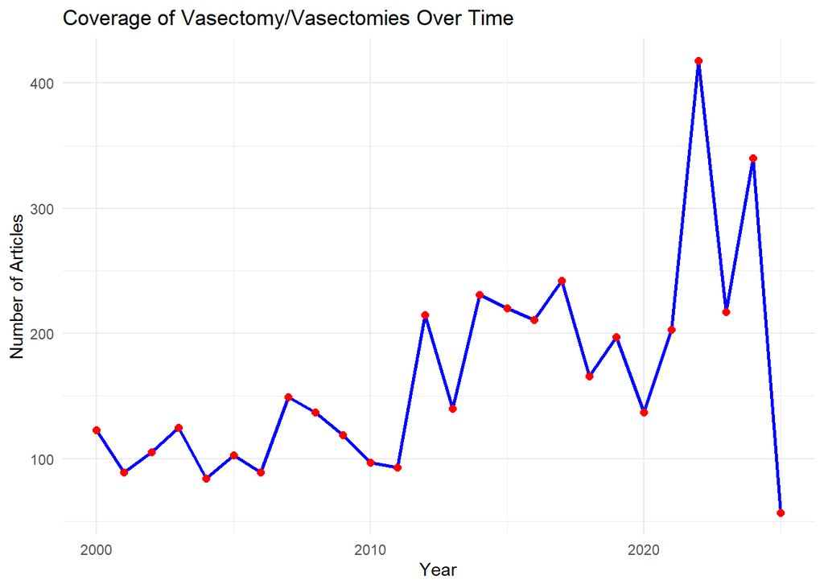

```r
library(readr)
Coverus <- read_csv("us_charts/CoverageoverTime_vasectomyvasectomies.csv")
Coverus <- janitor::clean_names(Coverus)
Coverus <- Coverus %>%
  mutate(covertime = as.Date(coverage_over_time))

p <- ggplot(Coverus, aes(x = covertime, y = coverage)) +
  geom_line(color = "blue", size = 1) +
  geom_point(color = "red", size = 2) +
  labs(title = "Coverage of Vasectomy/Vasectomies Over Time",
       x = "Year",
       y = "Number of Articles") +
  theme_minimal()
p
```

This shows that vasectomy coverage surged after the overturn of Roe v. Wade in 2022.

The Top publications of this coverage are:

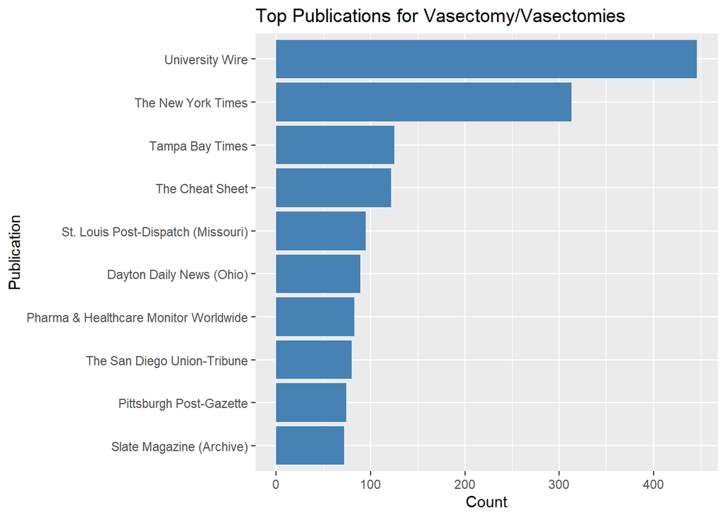

```r
top_pub <- read_csv("us_charts/TopPublications_vasectomyvasectomies.csv")
ggplot(top_pub, aes(x = reorder(Publication, Coverage), y = Coverage)) +
  geom_col(fill = "steelblue") +
  labs(title = "Top Publications for Vasectomy/Vasectomies",
       x = "Publication",
       y = "Count") +
  coord_flip()
```

```r
  theme_minimal()
```

[output not shown]

[output cut: 240 more lines]

[output not shown]

**In Addition–**

1. I will generate a word cloud as part of the statistical analysis of my dataset.
2. For inner coding validity check, I will also human code 150 articles from my sample and cross check it will topic modeling and machine coding.
3. I plan to incorporate network analysis as part of my data analysis strategy. First, I will identify the top 20 (or possibly 50) most frequently mentioned words in the dataset. In the resulting network, each word will be represented as a node, and an edge will be drawn between two nodes if the corresponding words co-occur in the same article. The thickness of each edge will represent the frequency with which the two words are mentioned together, while the size of each node will indicate the total number of times that word appears in the dataset.

   In addition, I will perform a similar network analysis using the top 20 (or 50) bigrams—pairs of words extracted from the text. This will help reveal which combinations of topics or words are most commonly discussed together, offering insights into prevalent themes and their interconnections.

# **The sample data below is using U.S. data**

```r
#data importing
library(readxl)
vasus <- read_excel("Results list us.xlsx",
    col_types = c("text", "date", "text",
        "text", "text", "numeric", "text",
        "numeric", "numeric", "text", "numeric",
        "text", "text", "text", "text", "text",
        "text", "numeric", "numeric", "numeric",
        "numeric"))
#This cleans column names
vasus <- janitor::clean_names(vasus)

#Using code, describe the number of rows and columns of the dataset
nrow(vasus)
```

```
## [1] 2000
```

```r
ncol(vasus)
```

```
## [1] 21
```

```r
print(paste0("The number of rows in the dataset is ", nrow(vasus), " and the number of columns in the dataset is ", ncol(vasus)))
```

```
## [1] "The number of rows in the dataset is 2000 and the number of columns in the dataset is 21"
```

### Create ggplot chart showing the distribution of the data over time

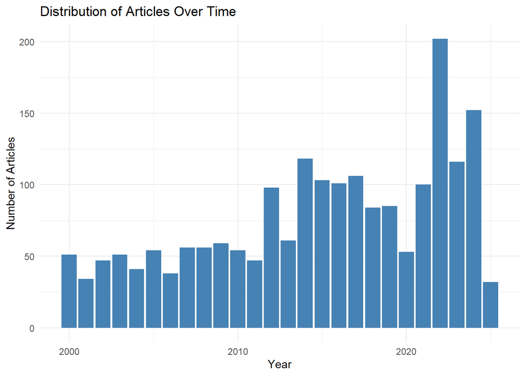

```r
vas_time <- vasus %>%
  mutate(year = year(published_date)) %>%
  group_by(year) %>%
  summarise(count = n()) %>%
  ungroup()

p <- ggplot(vas_time, aes(x = year, y = count)) +
  geom_bar(stat = "identity", fill = "steelblue") +
  labs(title = "Distribution of Articles Over Time",
       x = "Year",
       y = "Number of Articles") +
  theme_minimal()
print(p)
```

### Produce a list of top 20 bigrams

```r
#Tokenize the hlead column
vas_hlead <- str_replace_all(vasus$hlead, "- ", "")
vas_hlead_df <- tibble(vas_hlead,)

vas_tokenized <- vas_hlead_df %>%
  unnest_tokens(word,vas_hlead)

#remove stop words
data(stop_words)
vas_tokenized <- vas_tokenized %>%
  anti_join(stop_words, by = c("word" = "word")) %>%
  filter(word != "temp_file") %>%
  filter(word != "stories_corpus") %>%
  filter(!grepl('[0-9]', word))

bigrams <- vas_hlead_df %>%
  unnest_tokens(bigram, vas_hlead, token="ngrams", n=2)

bigrams
```

```
## # A tibble: 224,830 × 1
##    bigram
##    <chr>
##  1 woman accused
##  2 accused of
##  3 of convincing
##  4 convincing husband
##  5 husband to
##  6 to get
##  7 get vasectomy
##  8 vasectomy reveals
##  9 reveals the
## 10 the truth
## # ℹ 224,820 more rows
```

```r
#Filter out stop words.

bigrams1 <- bigrams %>%
  separate(bigram, c("word1", "word2"), sep = " ")

bigrams2 <- bigrams1 %>%
  filter(!word1 %in% stop_words$word) %>%
  filter(!word2 %in% stop_words$word) |>
  filter(!is.na(word1)) |>
  filter(!is.na(word2))

# word count and top 20 bigram
bigram3 <- bigrams2 %>%
  count(word1, word2, sort = TRUE)%>%
  top_n(20, n)

bigram3
```

```
## # A tibble: 20 × 3
##    word1              word2                  n
##    <chr>              <chr>              <int>
##  1 birth              control              440
##  2 supreme            court                138
##  3 planned            parenthood           134
##  4 health             care                 123
##  5 family             planning              81
##  6 male               birth                 81
##  7 reproductive       health                54
##  8 abortion           rights                53
##  9 control            pill                  53
## 10 health             insurance             53
## 11 nick               cannon                53
## 12 cheat              sheet                 50
## 13 vasectomy          reversal              50
## 14 male               contraceptive         49
## 15 sheet              http                  49
## 16 reproductive       rights                47
## 17 http               www.cheatsheet.com    46
## 18 www.cheatsheet.com delivered             46
## 19 march              madness               38
## 20 women's            health                38
```